# A Modest Proposal

Stats for data science

USCOTS May 14, 2019

# Imagine Intro Stat

Imagine there’s no *center*  
- It’s easy if you try.  
- No Null below us  
- Models explaining why

Imagine deviation  
- Cast away for good (ah ah ah)

Imagine diverse values  
- The math not hard to do  
- Difference not deviation  
- And forget error, too

Imagine all the models  
- Living life in peace

You can call that data science  
- But I’m not the only one  
- I hope someday you’ll join us  
- And statistics will have won

Imagine there’s no normal  
- I wonder if you can  
- No need for spread or center  
- Just predict what you can

Imagine all the data  
- Training models galore

You can call that data science  
- But I’m not the only one  
- I hope someday you’ll join us  
- And statistics will have won

# Re-imagining intro inference

Why we might want to do this ….

# Prediction

A common task in data science is to predict.

A common task in intro stats is to describe using a “typical” or “representative” value.

The *mean* is justified as the most representative value, except when it isn’t. Then we use the *median*.

- A median annual family income in the US in 2017 was $61,372. [Source](https://fred.stlouisfed.org/series/MEHOINUSA646N)

**Imagine that the central task in intro stats were to make a prediction**, rather than to describe what’s typical.

# Format?

Set a proper format for a prediction

In intro stats, we give students a confidence interval on the mean (but not usually the median).

- Not just a single value.
  - Silly to say, “I predict your family has an income of $61,372.”
  - That prediction will (almost) always be wrong.
  - Common sense will lead people to look for a noticeable difference, say $5000. So round to $55 to $65K.
- Need a format that can be *demonstrably right*, and demonstrably *wrong*.
  - 100% is too big.
  - 0% is too small (using the “typical”)
  - How about mean ± standard error
    - But the standard error depends on the sample size. Paradox: the more data we have, the more often our prediction will be wrong!

To think about a standard, imagine in each setting that we will have ten assays and we want to know if our prediction is right. - A 95% interval? 60% of settings we will have perfect predictions for the ten assays. So hard to know if our interval was too broad. - An 85% interval? In 20% of settings we will have perfect predictions, but more likely 7, 8, or 9 correct – 75% of assays.

Another criterion for a standard: be able to eyeball the prediction interval with, say, 50 to 100 data points. - 95% interval involves counting just 2 points from end: unreliable - 85% involves 7 points from end: more reliable.

# Group differences

Prediction of adult height in US

- Women 5’ 1" to 5’ 9".
- Men 5’ 5" to 6’ 1"

# Why do we use 95%?

Because we confuse description of variation with statistical “significance.”

Let the prediction interval demonstrate the variation that’s readily observable for two individuals.

# Spread without mean

First proposal: Focus on prediction, not “typical.” 85% summary interval.

How to define “spread” without a mean to refer it to?

- Could use length of the interval.

Second proposal: Define spread as the average difference between pairs of individuals.

Formulas:

$$D_2 = \sqrt{\frac{1}{n} \frac{1}{n-1} \sum_{i=1}^n \sum_{j=1}^n (x_i - x_j)^2}$$

… or …

$$D_1 = \frac{1}{n} \frac{1}{n-1} \sum_{i=1}^n \sum_{j=1}^n |x_i - x_j|$$

For fun, let’s see what these are for a standard normal distribution:

```
## [1] 1.096385
```

```
## [1] 1.376352
```

For a normal distribution,

- $D_2$ is $\sqrt{2} \times$ standard deviation
- $D_1$ is 20% smaller.
- Either can be used in what follows.

**More fun**: The $n-1$ term, obscure in the standard deviation, arises naturally here. In summing the $n^2$ terms, there will be $n$ of them that are $x_i - x_i$ and so must always be exactly zero.

# The 85% summary interval

The length of the 85% summary interval is $2 D_2$.

# CIs and p-values

Much of the inference part of conventional intro stats is about computing confidence intervals and p-values in a variety of settings:

- difference of means
- difference of proportions
- slope of regression line

# No statistics were harmed in the filming of this documentary

In the following, spread is measured using the length of the 85% summary interval.

You can still do all this by using the standard deviation instead.

# The procedure

1. Plot out data, draw in model.
2. From data and model, find R and sample size n. The picture will tell you R.
3. Measure effect size, e.g. difference in means or slope of regression line. Call it $\Delta$.
4. Calculate $F = n-2 \frac{R^2}{1-R^2}$.
5. 95% confidence interval on $\Delta$ is $\Delta \pm \sqrt{4/F}$.
6. “Significance”, but let’s call it … ?
   - $F = 4$ – one star (corresponds to about 0.05)
   - $F = 7$ – two stars (corresponds to about 0.01)
   - $F = 12$ – three stars (corresponds to about 0.001)

# The F table

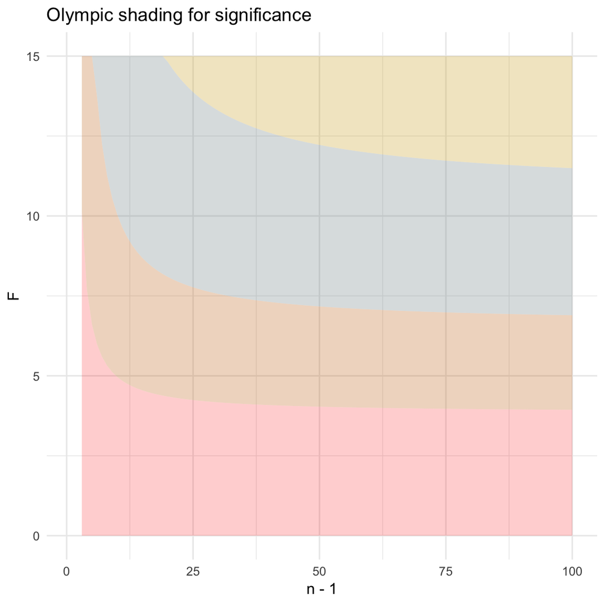

# Difference of means

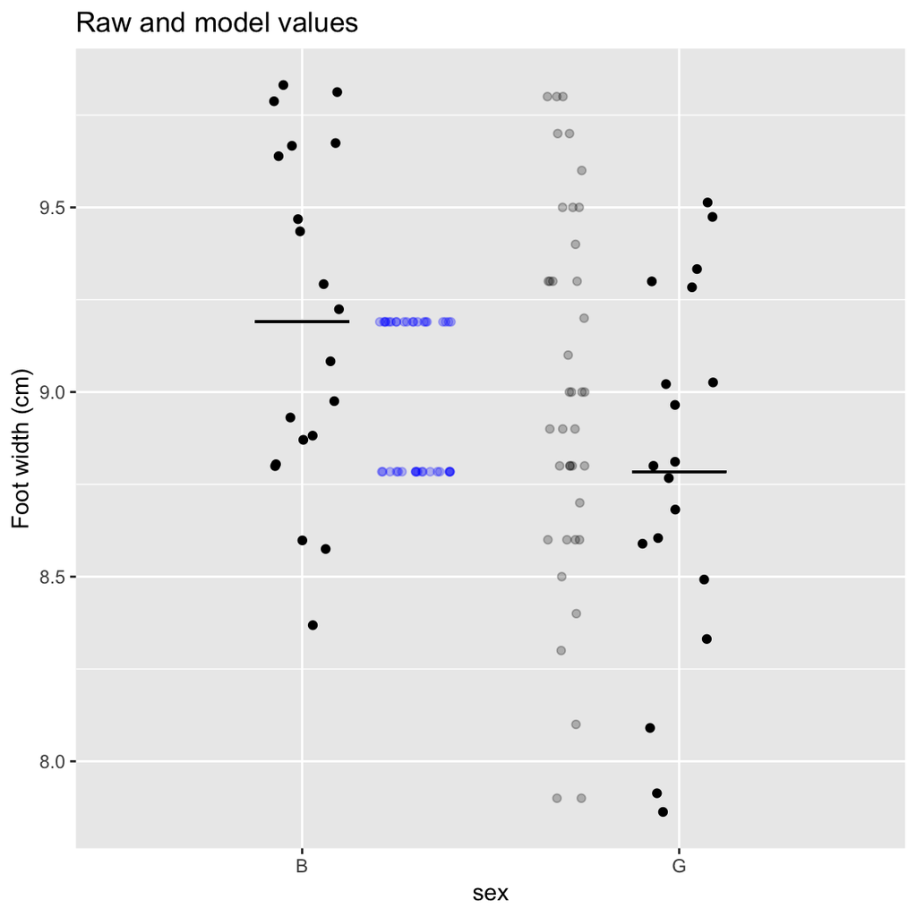

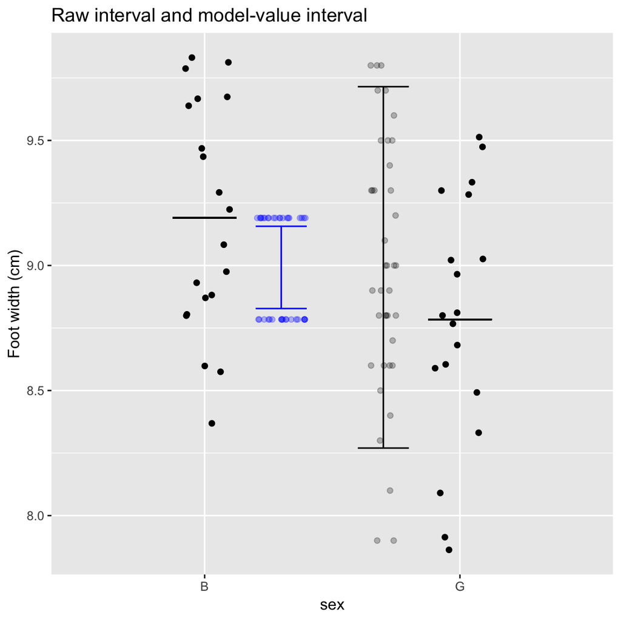

The ratio of the intervals is $R \approx 0.25$ (and $n = 39)$.

- **Difference** between the means: read it off the graph: ∆.
- **CI** on difference between means: ∆ (1 ± $\sqrt{\frac{1-R^2}{n-2}})$
- “**Significance**” is $(n-2) \frac{R^2}{1-R^2}$
  - One star when 4, two stars when 7, three stars when 12.

# Regression slope

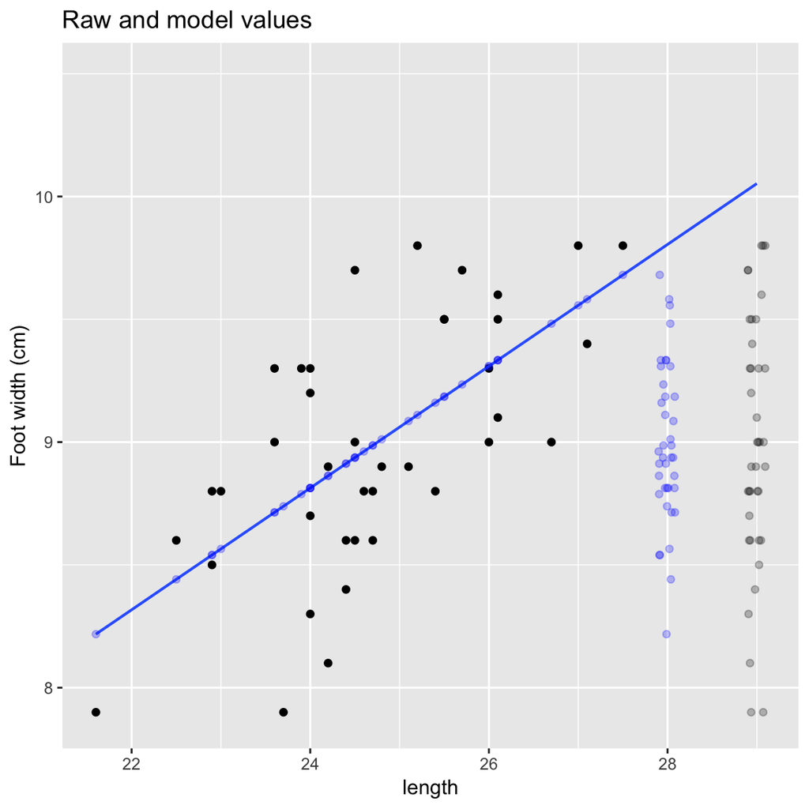

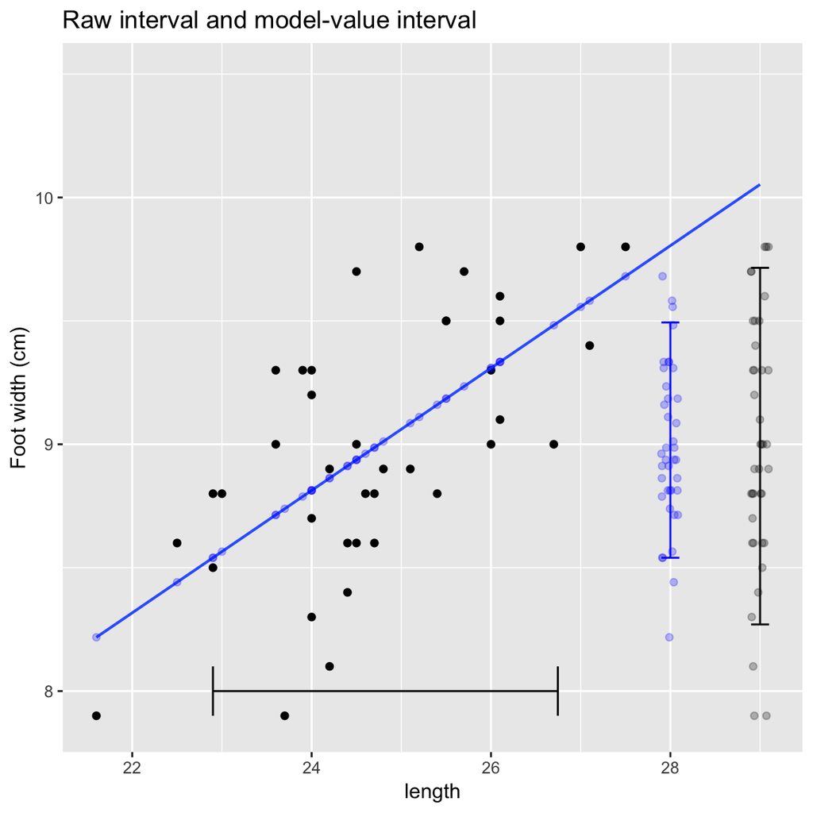

The ratio of the vertical intervals is about $R \approx 0.65$ (and $n = 39$).

- **Slope** is ratio of rise interval over run interval. Call it ∆.
- **CI** on slope: ∆ (1 ± $\sqrt{\frac{1-R^2}{n-2}})$
- “**Significance**” is $F = (n-2)\frac{R^2}{1-R^2}$
  - One star when 4, two stars when 7, three stars when 12.

# Difference in proportions

# Slope of proportion